# examenEstadistica2023

# Ejercicio N° 4 - Teorema Central del Límite (15 puntos)

En clase hemos visto que la media de variables Normales es una Normal. Ahora bien, ¿Ocurrirá lo mismo si las variables que se promedian no son normales?. Se plantea el siguiente ejercicio para que intenten resolver, de forma tal que descubran al Teorema Central del Límite. Repetir el proceso visto en clase mediante R cuando la variable aleatoria original se distribuye de la forma siguiente, 1. Poisson de parámetro λ = 1.5 2. Exponencial de parámetro μ = 2.5 3. Uniforme en el intervalo [10,30] 4. Weibull de parámetros shape = 2 y scale = 1. Realizar un Gráfico de Histograma y plotear la densidad de una variable normal para cada caso.

[figure not shown]

```r
# Function to generate n random variables with a Poisson distribution with parameter lambda = 1.5
mean_poisson <- function(n){
  return(mean(rpois(n, lambda = 1.5)))
}

# Plot the distribution of the mean of Poisson variables
n <- 100000
hist(mean_poisson(n), main = "Mean of Poisson variables", xlab = "Value", ylab = "Frequency")
curve(dnorm(x, mean = 1.5, sd = sqrt(1.5/n)), col = "red", add = TRUE)
```

[figure not shown]

```r
# Function to generate n random variables with an Exponential distribution with parameter mu = 2.5
mean_exponential <- function(n){
  return(mean(rexp(n, rate = 1/2.5)))
}

# Plot the distribution of the mean of Exponential variables
n <- 100000
hist(mean_exponential(n), main = "Mean of Exponential variables", xlab = "Value", ylab = "Frequency")
curve(dnorm(x, mean = 2.5, sd = sqrt(2.5/n)), col = "red", add = TRUE)
```

[figure not shown]

```r
# Function to generate n random variables with a Uniform distribution between 10 and 30
mean_uniform <- function(n){
  return(mean(runif(n, min = 10, max = 30)))
}

# Plot the distribution of the mean of Uniform variables
n <- 100000
hist(mean_uniform(n), main = "Mean of Uniform variables", xlab = "Value", ylab = "Frequency")
curve(dnorm(x, mean = 20, sd = sqrt(60/12/n)), col = "red", add = TRUE)
```

[figure not shown]

```r
# Function to generate n random variables with a Weibull distribution with parameters shape = 2 and scale = 1
mean_weibull <- function(n){
  return(mean(rweibull(n, shape = 2, scale = 1)))
}

# Plot the distribution of the mean of Weibull variables
n <- 100000
hist(mean_weibull(n), main = "Mean of Weibull variables", xlab = "Value", ylab = "Frequency")
curve(dnorm(x, mean = sqrt(pi/2), sd = sqrt((pi - 2)/2/n)), col = "red", add = TRUE)
```

# Ejercicio N° 5 - IC y Prueba de Hipótesis (15 puntos)

Proceda a cargar el siguiente dataset de un repositorio en github,

```r
url = "https://github.com/hllinas/DatosPublicos/blob/main/Estudiantes.Rdata?raw=false"
repmis::source_data(url)
```

```
## SHA-1 hash of the downloaded data file is:
## 6bf9d5a19779293538bd61d55d0662bdaf8100a1
```

```
## [1] "Estudiantes"
```

```r
datos <- Estudiantes
```

Realizar los siguientes ejercicios. Interprete todas sus respuestas. a) Considerar solamente las observaciones que van desde la 2 hasta la 35 y definir el data frame “datos2a35”. Verificar su tamaño, variables y estructura.

```r
# Se seleccionan las observaciones desde la 2 hasta la 35
datos2a35 <- datos[2:35, ]

# Se Verifica el tamaño del data frame
dim(datos2a35)
```

```
## [1] 34 46
```

```r
# Se Verifica las variables y estructura
str(datos2a35)
```

```
## Classes 'tbl_df', 'tbl' and 'data.frame':    34 obs. of  46 variables:
##  $ Observacion : num  2 3 4 5 6 7 8 9 10 11 ...
##  $ ID          : chr  "SB11201910004475" "SB11201910011427" "SB11201910041975" "SB11201910013623" ...
##  $ Sexo        : chr  "Masculino" "Masculino" "Masculino" "Femenino" ...
##  $ SexoNum     : num  1 1 1 0 0 0 0 0 1 0 ...
##  $ Edad        : chr  "21.07" "20.92" "18.41" "16.64" ...
##  $ Fuma        : chr  "Si" "Si" "Si" "Si" ...
##  $ Estatura    : chr  "Baja" "Alta" "Alta" "Alta" ...
##  $ Colegio     : chr  "Privado" "Privado" "Privado" "Privado" ...
##  $ Estrato     : num  2 2 2 1 2 1 1 2 1 1 ...
##  $ Financiacion: chr  "Beca" "Beca" "Beca" "Beca" ...
##  $ Acumulado   : chr  "3.96" "3.85" "3.69" "4.01" ...
##  $ P1          : chr  "2.3" "3.4" "2.5" "3.1" ...
##  $ P2          : chr  "4.9" "3.6" "4.2" "3.5" ...
##  $ P3          : chr  "3.7" "2.0" "5.0" "5.0" ...
```

[output cut: 32 more lines]

Todas los puntos siguientes resolverlo con el dataset “datos2a35”, b) Definir el objeto “Sexo” (género de los estudiantes). Conviértalo en factor y diga cuáles son sus respectivos niveles.

```r
# Se define el objeto "Sexo"
datos2a35$Sexo <- as.factor(datos2a35$Sexo)

# Se Verifica los niveles del objeto "Sexo"
levels(datos2a35$Sexo)
```

```
## [1] "Femenino"  "Masculino"
```

Como se observa en la salida str(datos2a35) la variable sexo era de tipo caracter y para atender la solicitud se convierte en factor y se vuelve asignar al data frame utilizado.

3. Construir una tabla de frecuencias para la variable Sexo y el diagrama de barras correspondiente.

```r
# Se Construye una tabla de frecuencias
table(datos2a35$Sexo)
```

```
##
##  Femenino Masculino
##        20        14
```

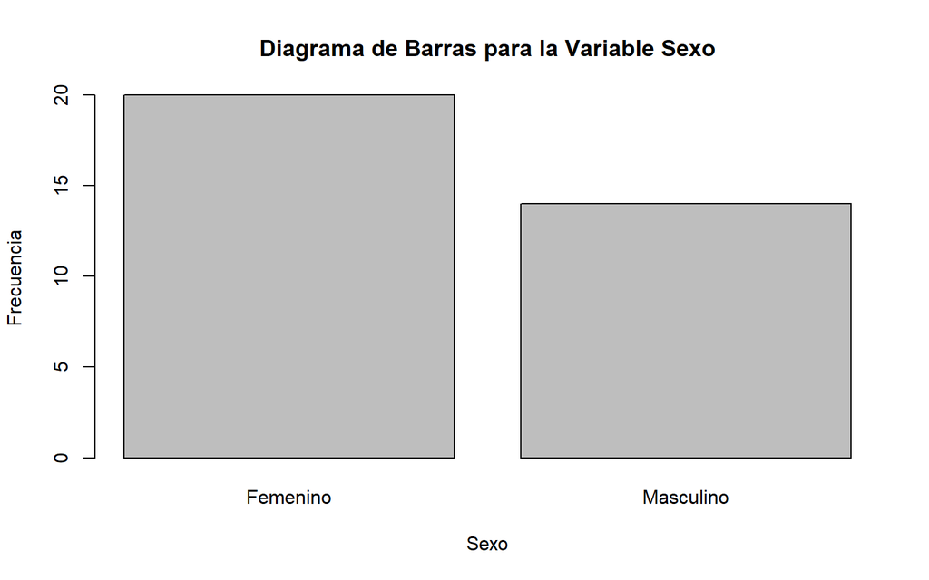

```r
# Se Construye un diagrama de barras
barplot(table(datos2a35$Sexo), xlab="Sexo", ylab="Frecuencia", main="Diagrama de Barras para la Variable Sexo")
```

Como se observa en la salida existen un mayor número de estudias categorizados con el sexo femenino (20) que los categorizados como masculinos (14).

4. Determinar la proporción de mujeres.

```r
prop_mujeres <- sum(datos2a35$Sexo == "Femenino")/length(datos2a35$Sexo)
```

Se observa que la proporción de mujeres corresponde al 58.82%.

5. Mediante el método de la región crítica: Al nivel del 5%, determine si el porcentaje poblacional de mujeres es menor o igual que el 30%. Escribir un resumen del enunciado del problema, verificar los supuestos, concluya, diga cuál es la fórmula, el valor de prueba, el valor crítico, la región crítica e interprete.

R/ Resumen del enunciado del problema: Se quiere determinar si el porcentaje poblacional de mujeres es menor o igual que el 30% al nivel del 5% de significancia.

Para realizar una prueba de hipótesis sobre la proporción poblacional de mujeres siendo menor o igual que el 30% con un nivel del 5%, se puede utilizar el método de la región crítica. Los supuestos para realizar esta prueba son:

- La muestra debe ser aleatoria y representativa de la población.
- Independencia de las muestras: La muestra de mujeres debe ser independiente de la muestra de hombres.
- Normalidad de la distribución: La distribución de la población de mujeres debe ser normal.

La hipótesis nula H0 sería que la proporción poblacional de mujeres es menor o igual que el 30%, mientras que la hipótesis alternativa Ha sería que la proporción poblacional de mujeres es mayor que el 30%.

Conclusión: Si se cumplen los supuestos, se puede utilizar el test Z para determinar si el porcentaje poblacional de mujeres es menor o igual que el 30%.

Fórmula: La fórmula para el test Z es:
$$Z= \frac{\overline{p} -
p}{\sqrt{\frac{p(1-p)}{n}}}$$
Z = (p̂ - p) / (√(p(1-p)/n))

donde:

p̂ es la proporción estimada de la muestra p es la proporción de la población n es el tamaño de la muestra

```r
#la proporción muestral fue calcalada con anterioridad y fue cargada en la variabel prop_mujeres
# n de la muestra esta determnado por 34 registros
# Se carga en la variable p_0 con el valor hipotetico del 30%
p_0=0.3
# En tal sentido, la formula seria la siguiente:
z=(prop_mujeres-p_0)/sqrt(0.3*(1-p_0)/length(datos2a35$Sexo))
#Se calcula la región critica, teniendo en cuenta que debido a que h0 <= 30% la region critica esta localizada en la zona derecha de la curva normal
# Se calcula el valor critico
qnorm(0.95)
```

```
## [1] 1.644854
```

```r
# Valor obtenido de la distribución z
z
```

```
## [1] 3.667558
```

Con relación a lo resultados obtenidos se puede concluir que hay evidencia suficiente para afirmar que el porcentaje poblacional de mujeres es mayor al 30%, por tal razón, se rechaza la hipótesis nula.

El hecho que el valor calculado sea mayor al crítico indica que se debe rechazar h0.

6. Mediante el método del P-valor: Determine si el porcentaje poblacional de mujeres es menor o igual que el 30%. Halle el P-valor, interprete y compare su decisión con el inciso (e).

Para el calculo del P-valor en R se utiliza el siguiente codigo

```r
pValor=1-pnorm(z)
pValor
```

```
## [1] 0.0001224391
```

Debido a que el P-valor es menor al nivel de significancia se rechaza la h0, se concluye que no hay evidencia suficiente para afirmar que el porcentaje poblacional de mujeres es menor o igual que el 30%, esta sería la misma medida obtenido a través del método de región critica.

Se recuerda la regla de decisión: - Se rechaza H0 cuando P-valor≤α - No se rechaza H0 cuando P-valor>α

7. Realizar la misma prueba del inciso (h) con la función prop.test y compare los resultados obtenidos.

```r
ejerG <- prop.test(length(datos2a35$Sexo), n=34, p = 0.3, alternative = "greater" )
ejerG$p.value
```

```
## [1] 1.393396e-18
```

Como se observa en el resultado obtenido, el valor del p-valor sigue siendo menor al nivel de significancia, por esta razón se rechaza h0, como en los ejercicios anteriores.

8. Construir un intervalo del 95% de confianza para la proporción poblacional de mujeres y compare los resultados obtenidos en los incisos anteriores.

El intervalo de confianza se puede construir utilizando la siguiente fórmula:

prop_mujeres ± z_alfa/2 * sqrt(prop_mujeres * (1 - prop_mujeres) / n)

donde:

z_alfa/2 es la mitad del valor crítico de la distribución normal estándar para un nivel de confianza del 95%, que es aproximadamente 1.96 prop_mujeres es la estimación de la proporción de mujeres en la muestra n es el número total de estudiantes en la muestra

```r
# Calculo de la varianza de la proporción de mujeres
var_prop_mujeres <- prop_mujeres * (1 - prop_mujeres) / 34

# Calculao de la desviación estándar de la proporción de mujeres
sd_prop_mujeres <- sqrt(var_prop_mujeres)

# Calculo del intervalo de confianza del 95%
ci_lower <- prop_mujeres - 1.96 * sd_prop_mujeres
ci_upper <- prop_mujeres + 1.96 * sd_prop_mujeres

# Impresión del intervalo de confianza
ci_lower
```

```
## [1] 0.4228044
```

```r
ci_upper
```

```
## [1] 0.7536662
```

Como se observa en el resultado obtenido, el intervalo de confianza del 95% arroja que la proporción de las mujeres en la población puede estar entre el rango del 42.28 % - 75.36 %, eso con relación a lo observado en la hipótesis nula, que en los ejercicios anterior esta fue rechazada, informando que no había evidencia suficiente para afirmar que la proporción de las mujeres fuera o estuviera por debajo de 30%.

# Ejercicio N° 6 - Regresión Lineal Simple (15 puntos)

Una analista de deportes quiere saber si existe una relación entre la cantidad de bateos que realiza un equipo de béisbol y el número de runs que consigue. En caso de existir y de establecer un modelo, podría predecir el resultado del partido.

```r
equipos <- c("Texas","Boston","Detroit","Kansas","St.","New_S.","New_Y.",
"Milwaukee","Colorado","Houston","Baltimore","Los_An.","Chicago",
"Cincinnati","Los_P.","Philadelphia","Chicago","Cleveland","Arizona",
"Toronto","Minnesota","Florida","Pittsburgh","Oakland","Tampa",
"Atlanta","Washington","San.F","San.I","Seattle")
numero_bateos <- c(5659, 5710, 5563, 5672, 5532, 5600, 5518, 5447, 5544, 5598,
5585, 5436, 5549, 5612, 5513, 5579, 5502, 5509, 5421, 5559,
5487, 5508, 5421, 5452, 5436, 5528, 5441, 5486, 5417, 5421)
runs <- c(855, 875, 787, 730, 762, 718, 867, 721, 735, 615, 708, 644, 654, 735,
667, 713, 654, 704, 731, 743, 619, 625, 610, 645, 707, 641, 624, 570,
593, 556)
datos <- data.frame(equipos,numero_bateos,runs)
head(datos)
```

```
##   equipos numero_bateos runs
## 1   Texas          5659  855
## 2  Boston          5710  875
## 3 Detroit          5563  787
## 4  Kansas          5672  730
## 5     St.          5532  762
## 6  New_S.          5600  718
```

Se solicita responder lo siguiente, 1) Realizar una visualización gráfica que permita determinar la relación entre ambas variables.

Para esto se puede usar un scatterplot que permita identificar la distribucion de los puntos y determinar la relacion entre ellos, el codigo en R sería el siguiente:

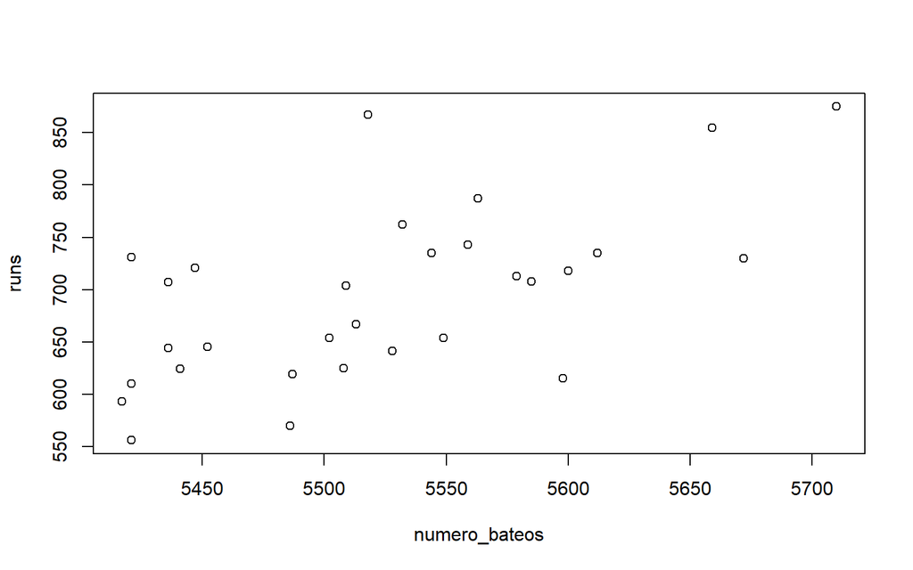

```r
plot(numero_bateos, runs)
```

Este gráfico permite ver si existe una relación lineal entre las dos variables y su dirección. Inicialmente se puede ver que existe una relación entre las variables con pendiente positiva.

2. Poner a prueba la conjetura de significancia estadística del coeficiente de correlación lineal poblacional entre ambas variables con un nivel de significación del 5%.

Para poner a prueba la conjetura de significancia estadística del coeficiente de correlación lineal poblacional, se puede calcular el coeficiente de correlación Pearson (r) y la prueba t correspondiente. El código en R se presenta a continuación:

```r
cor.test(numero_bateos, runs)
```

```
##
##  Pearson's product-moment correlation
##
## data:  numero_bateos and runs
## t = 4.0801, df = 28, p-value = 0.0003388
## alternative hypothesis: true correlation is not equal to 0
## 95 percent confidence interval:
##  0.3209675 0.7958231
## sample estimates:
##      cor
## 0.610627
```

El resultado indica el valor de r y el valor p para la hipótesis nula de que el coeficiente de correlación lineal poblacional es igual a cero. Como se observa el valor p es menor que el nivel de significación establecido (0.05), en tal sentido, se puede rechazar la hipótesis nula y concluir que existe una relación lineal significativa entre las dos variables.

3. Construir un modelo de regresión lineal simple. Identifique la variable respuesta y el regresor del modelo. Interpretar los resultados de los parámetros estimados.

Para construir un modelo de regresión lineal simple, se puede usar la función lm(). La variable numero_bateos es el regresor y runs es la variable respuesta. A continuación se presenta el codigo en R:

```r
modelo <- lm(runs ~ numero_bateos, data = datos)
summary(modelo)
```

```
##
## Call:
## lm(formula = runs ~ numero_bateos, data = datos)
##
## Residuals:
##     Min      1Q  Median      3Q     Max
## -125.58  -47.05  -16.59   54.40  176.87
##
## Coefficients:
##                 Estimate Std. Error t value Pr(>|t|)
## (Intercept)   -2789.2429   853.6957  -3.267 0.002871 **
## numero_bateos     0.6305     0.1545   4.080 0.000339 ***
## ---
## Signif. codes:  0 '***' 0.001 '**' 0.01 '*' 0.05 '.' 0.1 ' ' 1
##
## Residual standard error: 66.47 on 28 degrees of freedom
## Multiple R-squared:  0.3729, Adjusted R-squared:  0.3505
## F-statistic: 16.65 on 1 and 28 DF,  p-value: 0.0003388
```

4. Realizar una estimación por intervalos de confianza para la predicción del modelo obtenido con una confianza del 95/. Interpretar los resultados.

Para realizar una estimación por intervalos de confianza para la predicción del modelo, se puede utilizar la función predict(). El argumento interval se usa para especificar el intervalo de confianza.

```r
predicciones <- predict(modelo, interval = "confidence", level = 0.95)
```

5. Incorporar al gráfico del punto 1) el modelo estimado.

Para incorporar el modelo estimado al gráfico del punto 1), se puede usar la función abline().

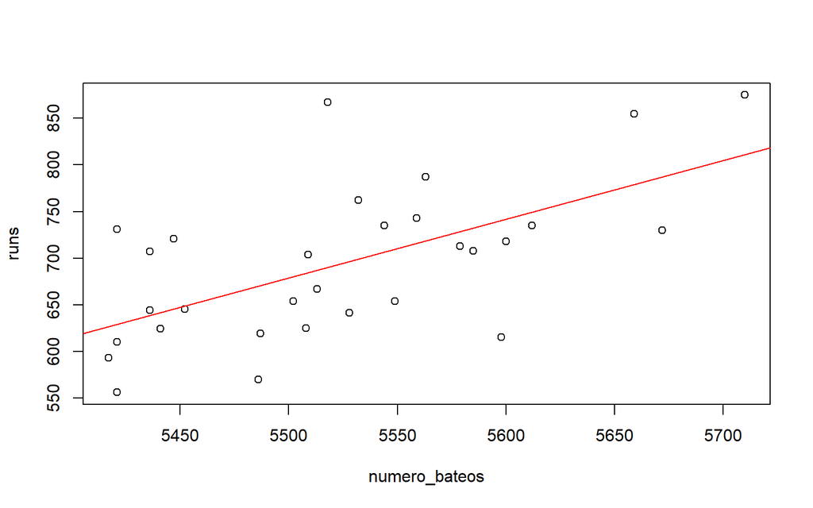

```r
plot(numero_bateos, runs)
abline(modelo, col = "red")
```

Este gráfico muestra la línea de regresión superpuesta en el scatterplot.

6. Verificar los supuestos del modelo de regresión lineal.

Los supuestos del modelo de regresión lineal son importantes para garantizar que los resultados obtenidos a partir del modelo sean válidos y fiables. Estos supuestos incluyen:

- Linealidad: La relación entre la variable respuesta y el regresor debe ser lineal.
- Independencia: Las observaciones deben ser independientes entre sí.
- Homocedasticidad: La varianza de los errores debe ser constante en todo el rango del regresor.
- Normalidad: Los errores deben ser normales y tener una distribución normal.
- Ausencia de multicolinealidad: No debe existir una correlación fuerte entre el regresor y otras variables.

En los resultados obtenidos se observa: Residual standard error: 66.47 on 28 degrees of freedom Multiple R-squared: 0.3729, Adjusted R-squared: 0.3505 F-statistic: 16.65 on 1 and 28 DF, p-value: 0.0003388

Estos se pueden interpretar de la siguiente forma: Residual standard error: El error estándar residual (RSE) es una medida de la variabilidad residual, es decir, la variabilidad de la respuesta que no es explicada por el modelo. Un RSE más pequeño indica un mejor ajuste del modelo. En este caso, el RSE es de 66.47, lo que significa que los residuos tienen una variabilidad moderada.

Multiple R-squared: El R-cuadrado múltiple es una medida de qué tanto el modelo explica la variabilidad de la respuesta. Un R-cuadrado más cercano a 1 indica un mejor ajuste del modelo. En este caso, el R-cuadrado múltiple es de 0.3729, lo que significa que el modelo explica el 37.29% de la variabilidad de los datos.

F-statistic: La estadística F es una medida de qué tanto el modelo es significativo en general. Un valor más grande de F indica un modelo más significativo. En este caso, el valor F es de 16.65, con un p-value de 0.0003388, lo que significa que existe una relación significativa entre las variables en el modelo.